# EB3I n1 2025 scRNAseq - **PRE-PROCESSING (III)** - Filtering, cell cyle, cell doublets

# 1 PREAMBLE

## 1.1 Purpose of this session

This file describes the different steps to perform the **third part** of the single cell RNAseq data analysis training course for the **EB3I n1 2025**, covering these steps :

- **Filtering** of bad cells and extreme low-expression features
- Estimation of the **cell cycle** phase
- Identification and removal of **cell doublets**

# 2 Start Rstudio

- Using the [OpenOnDemand/Rstudio cheat sheet](https://moodle.france-bioinformatique.fr/pluginfile.php/1475/mod_folder/content/0/OoD_R_Rstudio.html), connect to the [OpenOnDemand portal](https://ondemand.cluster.france-bioinformatique.fr) and **create a Rstudio session** with the right resource requirements.

# 3 Warm-up

- We set **common parameters** we will use throughout this session :

```r
# setparam


## Set your project name
# WARNING : Do not just copy-paste this ! It's MY project name ! Put YOURS !!
project_name <- "ebaii_sc_teachers"

## Control if the project_name exists on the cluster
cat('PATH CHECK : ', dir.exists(paste0('/shared/projects/', project_name)))
```

**Show output**

```
PATH CHECK :  TRUE
```

```r
## Seed for the RNG
my_seed <- 1337L

## Minimum cells with counts to keep a feature
min_cells <- 5
```

# 4 Prepare the data structure

We will do the same as for former steps, just changing the session name.

## 4.1 Main directory

```r
# maindir

## Preparing the path
TD_dir <- paste0("/shared/projects/", project_name, "/SC_TD")

## Creating the root directory
# dir.create(path = TD_dir, recursive = TRUE)

## Print the root directory on-screen
print(TD_dir)
```

```
[1] "/shared/projects/ebaii_sc_teachers/SC_TD"
```

## 4.2 Current session

```r
# sessiondir

## Creating the session (Preproc.3) directory
session_dir <- paste0(TD_dir, "/03_Preproc.3")
dir.create(path = session_dir, recursive = TRUE)

## Print the session directory on-screen
print(session_dir)
```

```
[1] "/shared/projects/ebaii_sc_teachers/SC_TD/03_Preproc.3"
```

## 4.3 Input directory

```r
# indir

## Creating the INPUT data directory
input_dir <- paste0(session_dir, "/DATA")
dir.create(path = input_dir, recursive = TRUE)

## Print the input directory on-screen
print(input_dir)
```

```
[1] "/shared/projects/ebaii_sc_teachers/SC_TD/03_Preproc.3/DATA"
```

## 4.4 Genelists directory

This is a directory where we will store additional information from knowledge bases about genes used to estimate the cell cycle phase of cells.

```r
# resdir

res_dir <- paste0(TD_dir, "/Resources")
glist_dir <- paste0(res_dir, "/Genelists")

## Create the directory
dir.create(path = glist_dir, recursive = TRUE)

## Print the resources directory on-screen
print(glist_dir)
```

```
[1] "/shared/projects/ebaii_sc_teachers/SC_TD/Resources/Genelists"
```

## 4.5 Output directory

```r
# outdir

## Creating the OUTPUT data directory
output_dir <- paste0(session_dir, "/RESULTS")
dir.create(path = output_dir, recursive = TRUE)

## Print the output directory on-screen
print(output_dir)
```

```
[1] "/shared/projects/ebaii_sc_teachers/SC_TD/03_Preproc.3/RESULTS"
```

# 5 Reload the Seurat Object

- We can reload the object we saved at the former step

```r
# dataload


## This is the path to the current EB3I backup
sessionid <- '2538_eb3i_n1_2025'


## The latest Seurat object saved as RDS (name)
sobj_file <- "02_TD3A_S5_Metrics_31053.4587.RDS"

## The latest Seurat object saved as RDS (full path)
sobj_path <- paste0(TD_dir,
                    "/02_Preproc.2/RESULTS/",
                    sobj_file)

force <- FALSE  ## To force a re-download of a Zenodo-hosted backup
local <- FALSE  ## To force a loading from a local backup

## In case of error/lost data : force a reload from a Zenodo backup repository
if(force) {
  zen_id <- "14035293"
  zen_backup_file <- paste0("https://zenodo.org/records/",
                            zen_id,
                            "/files/",
                            sobj_file)
  ## Recreate the expected path if it does not exist
  dir.create(path = dirname(sobj_path), recursive = TRUE)
  ## Download the file
  download.file(url = zen_backup_file,
                destfile = sobj_path)
}

## In case of error/lost data : force a reload from a local backup repository
if(local) {
  sobj_path <- paste0(
    "/shared/projects/", sessionid, "/atelier_scrnaseq/TD/BACKUP/RDS/",
    sobj_file)
}

## Load the object
sobj <- readRDS(file = sobj_path)
```

Now, we finally have all the metrics and bias sources we could use, so we can actually get to the filtering step.

# 6 Filtering

## 6.1 Features

- As already explained, the **sparsity** of the count matrix is high, *very* high.
- To the point that there probably are some features that have **so low expression** level that they were only counted in **very few cells**. As such, they have absolutely **no chance** to characterize any cell type, nor harbor some variation between different cell types.
- As such, we should **discard** these features

What are the actual dimensions of our expression data ?

```r
# seudim1

## Dimensions of our Seurat object
dim(sobj)
```

**Show output**

```
[1] 31053  4587
```

We want to remove the features that are expressed in less than **5** cells.

First, we quantify, for each feature, the number of cells with `0` count.

```r
# nfeatdiff

## Compute the amount of 0s per feature
nFeat_zero <- sparseMatrixStats::rowCounts(
  x = SeuratObject::GetAssayData(
    object = sobj,
    assay = "RNA",
    layer = "counts"),
  value = 0)

## Inversion : computing the number of cells with at least one count, per feature
nFeat_nonzero <- ncol(sobj) - nFeat_zero

## Identify those with at least 5 cells with expression
nFeat_keep <- nFeat_nonzero >= min_cells

## Quantify the selected ones
table(nFeat_keep)
```

**Show output**

```
nFeat_keep
FALSE  TRUE
18545 12508
```

And now we can **discard** features expressed in less than 5 cells :

```r
# prefeatfiltviz

## Create a temporary object
sobj_VIZ_pre <- sobj

## Usual set of "U can't C me" functions
sobj_VIZ_pre <- Seurat::NormalizeData(object = sobj_VIZ_pre, verbose = FALSE)
sobj_VIZ_pre <- Seurat::ScaleData(object = sobj_VIZ_pre, verbose = FALSE)
sobj_VIZ_pre <- Seurat::FindVariableFeatures(object = sobj_VIZ_pre, verbose = FALSE)
sobj_VIZ_pre <- Seurat::RunPCA(object = sobj_VIZ_pre, npcs = 21, verbose = FALSE)
sobj_VIZ_pre <- Seurat::RunUMAP(object = sobj_VIZ_pre, dims = c(1:20), verbose = FALSE)

## Cell space visualization
dp_pre <- Seurat::DimPlot(
  object = sobj_VIZ_pre,
  reduction = 'umap') + Seurat::DarkTheme()
print(dp_pre)
```

**Show plot**

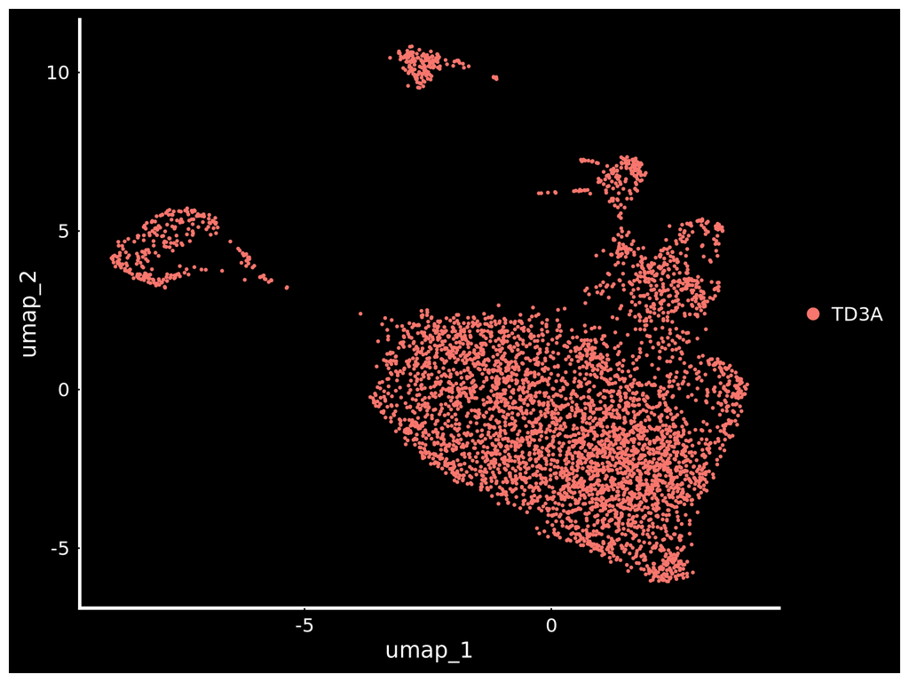

```r
## Remove temporary object
rm(sobj_VIZ_pre)
```

```r
# featsel

## Restrict the Seurat object
sobj <- subset(x = sobj, features = rownames(sobj)[nFeat_keep])
```

What are the Seurat object dimensions, now ?

```r
# seudim2

dim(sobj)
```

**Show output**

```
[1] 12508  4587
```

We can **visualize the cell space** after this features filtering

```r
# postfeatfiltviz

## Create a temporary object
sobj_VIZ_post <- sobj

## Usual set of "U can't C me" functions
sobj_VIZ_post <- Seurat::NormalizeData(object = sobj_VIZ_post, verbose = FALSE)
sobj_VIZ_post <- Seurat::ScaleData(object = sobj_VIZ_post, verbose = FALSE)
sobj_VIZ_post <- Seurat::FindVariableFeatures(object = sobj_VIZ_post, verbose = FALSE)
sobj_VIZ_post <- Seurat::RunPCA(object = sobj_VIZ_post, npcs = 21, verbose = FALSE)
sobj_VIZ_post <- Seurat::RunUMAP(object = sobj_VIZ_post, dims = c(1:20), verbose = FALSE)

## Cell space visualization
dp_post <- Seurat::DimPlot(
  object = sobj_VIZ_post,
  reduction = 'umap') + Seurat::DarkTheme()
print(dp_post)
```

**Show plot**

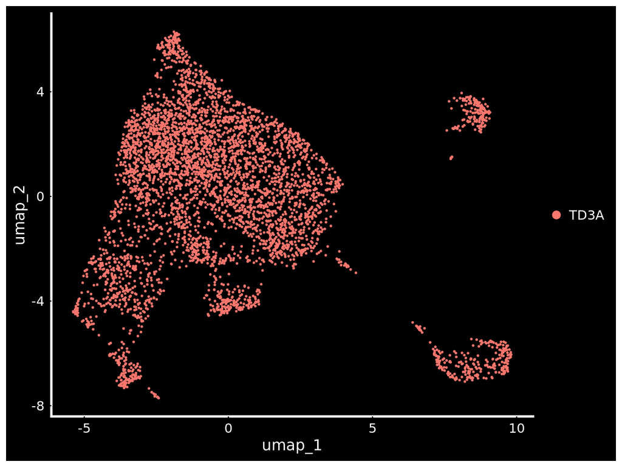

```r
## Remove temporary object
rm(sobj_VIZ_post)
```

Merging plots for ease of visualization :

```r
# c5_pw

## Using the patchwork package to merge plots (and ggplot2 to add titles)
patchwork::wrap_plots(
  list(
    dp_pre & ggplot2::ggtitle(label = "BEFORE"),
    dp_post & ggplot2::ggtitle(label = "AFTER")),
  nrow = 1)
```

**Show plot**

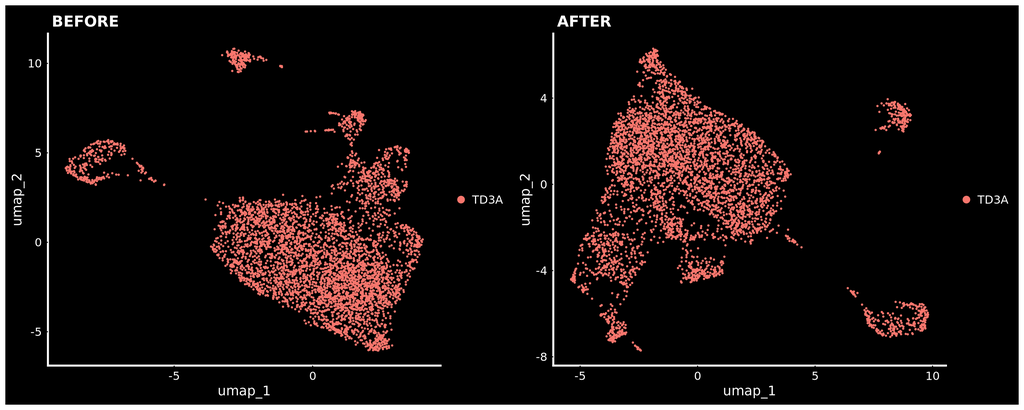

- **Question** :

  ```r
  # q_mincell

  Do you see any difference when comparing before vs after features filtering ?
  ```

  ```r
  # a_mincell

  ## . Not much changed
  ##
  ## . This is expected, as we removed features with almost no expression
  ```

## 6.2 Cells

We are now able to **apply all the filtering strategies** we established for each QC metric.

- Apply the filter

  ```r
  # cellfilt

  ## Seurat object BEFORE cell filtering
  dim(sobj)
  ```

  **Show output**

  ```
  [1] 12508  4587
  ```

  ```r
  ## Apply cell filtering
  sobj <- subset(x = sobj, cells = colnames(sobj)[sobj$fail_qc == "pass"])

  ## Seurat object AFTER cell filtering
  dim(sobj)
  ```

  **Show output**

  ```
  [1] 12508  4278
  ```

We can **visualize the cell space** since this cell filtering

```r
# postcellfiltviz

## Create a temporary object
sobj_VIZ <- sobj

## Usual set of "U can't C me" functions
sobj_VIZ <- Seurat::NormalizeData(object = sobj_VIZ, verbose = FALSE)
sobj_VIZ <- Seurat::ScaleData(object = sobj_VIZ, verbose = FALSE)
sobj_VIZ <- Seurat::FindVariableFeatures(object = sobj_VIZ, verbose = FALSE)
sobj_VIZ <- Seurat::RunPCA(object = sobj_VIZ, npcs = 21, verbose = FALSE)
sobj_VIZ <- Seurat::RunUMAP(object = sobj_VIZ, dims = c(1:20), verbose = FALSE)

## Cell space visualization
dp_VIZ <- Seurat::DimPlot(
  object = sobj_VIZ,
  reduction = 'umap') + Seurat::DarkTheme()
print(dp_VIZ)
```

**Show plot**

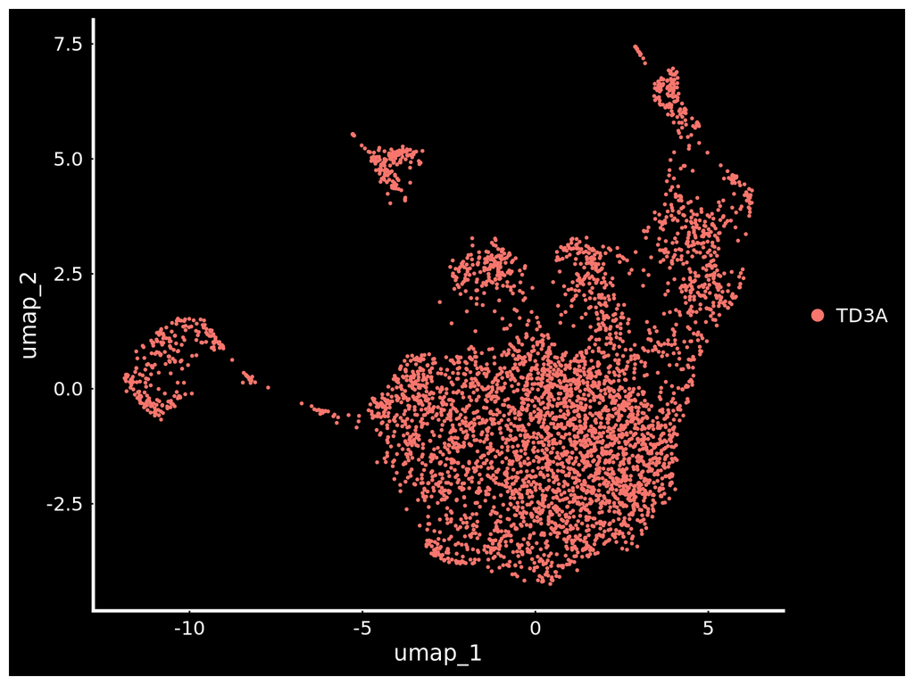

```r
## Discard the temp object
rm(sobj_VIZ)
```

One can associate the visualization after filtering cells :

```r
# cfilt_umaps

## Using the patchwork package to merge plots (and ggplot2 to add titles)
patchwork::wrap_plots(
  list(
    dp_post & ggplot2::ggtitle(label = "Features (count<5) filtered"),
    dp_VIZ & ggplot2::ggtitle(label = "Cells filtered (metrics)")),
  nrow = 1)
```

**Show plot**

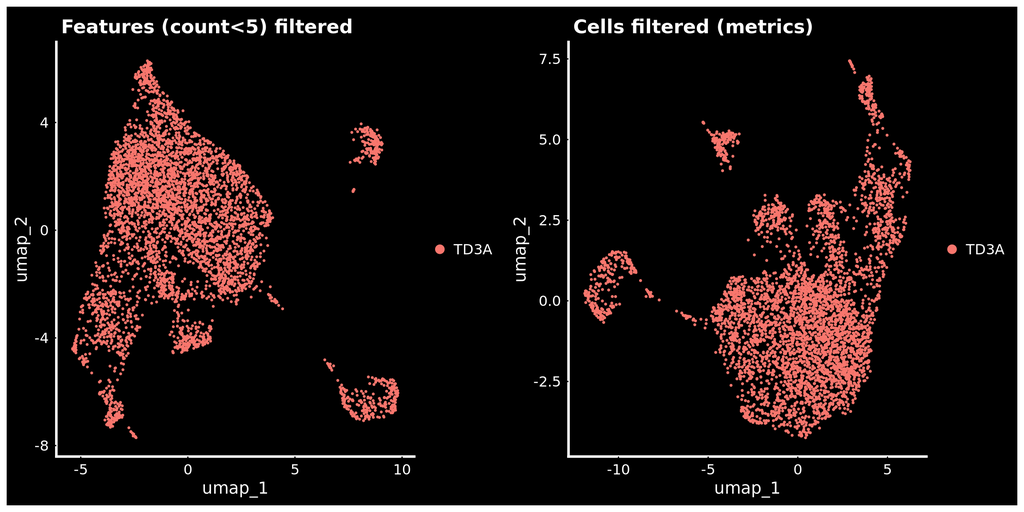

- **Question**

[output not shown]

# 7 Save the Seurat object

We will **save our Seurat object** that now contains **filtered cells and features** :

```r
# saverds1

## Save our Seurat object (rich naming)
out_name <- paste0(
          output_dir, "/", paste(
            c("03", Seurat::Project(sobj), "S5",
              "Metrics.Filtered", paste(
                dim(sobj),
                collapse = '.'
              )
            ), collapse = "_"),
            ".RDS")

## Check
print(out_name)
```

```
[1] "/shared/projects/ebaii_sc_teachers/SC_TD/03_Preproc.3/RESULTS/03_TD3A_S5_Metrics.Filtered_12508.4278.RDS"
```

```r
## Write on disk
saveRDS(object = sobj,
        file = out_name)
```

# 8 Cell cycle scores

## 8.1 Download gene lists

- We will directly retrieve data from Zenodo to your `input_dir` :

  ```r
  # dlzengl

  ## Zenodo ID
  zen_id <- '14101506'

  ### Named files (will be used later on !)
  cc_file <- "mus_musculus_Seurat_cc.genes_20191031.rds"

  ## Filename(s) to retrieve
  toget_files <- c(cc_file)

  ## Folder to store retrieved files
  local_folder <- glist_dir

  ## Use local backup ?
  backup <- FALSE
  if(backup) message("Using local backup !")

  ## Force download ?
  force <- FALSE
  if(force) message("Forcing (re)download !")

  ### Define remote folder
  remote_folder <- if (backup) {
    paste0("/shared/projects/", sessionid, "/atelier_scrnaseq/TD/RESOURCES/GENELISTS/")
  }  else {
    paste0("https://zenodo.org/records/", zen_id, "/files/")
  }

  ### Reconstruct the input paths
  remote_path <- paste0(remote_folder, "/", toget_files)

  ### Reconstruct the output paths
  local_path <- paste0(local_folder, "/", toget_files)

  ## Retrieve files (if they don't exist), in loop
  for (tg in seq_along(toget_files)) {
    ## If the file does not locally exist
    if (!file.exists(local_path[tg]) | force) {
      ## Retrieve data
      if(backup) {
        file.copy(from = remote_path[tg],
                  to = local_path[tg])
      } else {
        download.file(url = remote_path[tg],
                      destfile = local_path[tg])
      }
      ## Check if downloaded files exist locally
      if(file.exists(local_path[tg])) message("\tOK")
    } else message(paste0(toget_files[tg], " already downloaded !"))
  }
  ```

## 8.2 Load gene lists

```r
# cc_load

## The cell cycle gene lists file
cc_file <- paste0(glist_dir,
                  "/",
                  cc_file)

## Load the cell cycle reference genes lists
cc_genes <- readRDS(file = cc_file)

## Have a look on its content
str(cc_genes)
```

**Show output**

```
List of 2
 $ s.genes  : chr [1:43] "Mcl5" "Pcna" "Tyms" "Fen1" ...
 $ g2m.genes: chr [1:54] "Hmgb2" "Cdk1" "Nusap1" "Ube2c" ...
```

- **Question**

  ```r
  # q_cc_check

  As explained, we will use gene lists extracted from community knowledge.
  Our data contain values for genes also, so we will cross them.

  Is there something we should check ?
  ```

  ```r
  # a_cc_check

**Beyond** :

1. Write a code that performs this check
2. Add a code to adjust the content of the gene lists accordingly (remove genes from the gene lists that are not present in our dataset)
3. *(NOTE : this is actually not needed as already checked and corrected by the cell cyle estimation method we will use)*

```r
# b_cc_answer

## Check if our data genes cover the gene lists
lapply(cc_genes, function(x) x %in% rownames(sobj))

## Remove genes not in sobj
cc_genes <- lapply(cc_genes, function(gl) { gl[gl %in% rownames(sobj)] })

## Check the modification
str(cc_genes)

## Check that all genes are available in sobj
all(unique(unlist(cc_genes)) %in% rownames(sobj))
```

## 8.3 Estimation

- Let’s perform this estimation. But how ?

  ```r
  # h_CellCycleScoring

  ## Reading the function help page
  ?Seurat::CellCycleScoring
  ```

- Run the cell-cycle estimation

  ```r
  # cc_run

  ## Creating a temporary object
  sobj_CCS <- sobj

  sobj_CCS <- Seurat::NormalizeData(object = sobj_CCS, verbose = FALSE)

  ## Perform the estimation
  set.seed(my_seed)
  sobj_CCS <- Seurat::CellCycleScoring(
    object = sobj_CCS,
    s.features = cc_genes$s.genes,
    g2m.features = cc_genes$g2m.genes,
    # assay = 'RNA, ## Seurat v4
    layer = 'RNA', ## Seurat v5
    nbin = 24,
    seed = my_seed)

  ## Transfering score from the temp object to the real one
  sobj$CC_Seurat_S.Score <- sobj_CCS$S.Score
  sobj$CC_Seurat_G2M.Score <- sobj_CCS$G2M.Score
  sobj$CC_Seurat_Phase <- as.factor(sobj_CCS$Phase)

  ## Add "S minus G2M" score
  sobj$CC_Seurat_SmG2M.Score <- sobj$CC_Seurat_S.Score - sobj$CC_Seurat_G2M.Score

  ## Discard temp object
  rm(sobj_CCS)
  ```

- Description of the object to see the data added

## 8.4 Visualization

As usual, we can visualize the results as violins :

```r
#vlncc

Seurat::VlnPlot(object = sobj,
                features = c("CC_Seurat_S.Score",
                             "CC_Seurat_G2M.Score",
                             "CC_Seurat_SmG2M.Score"))
```

**Show plot**

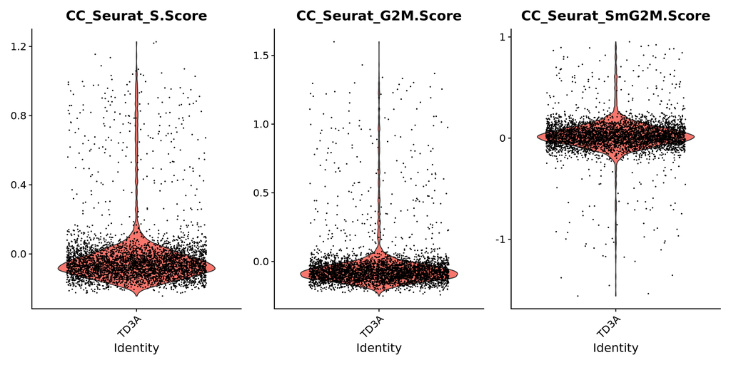

But it’s not that easy to interpret…

Let’s plot it in the cell space

### 8.4.1 Estimated cell phase :

```r
# vizccp

## Creating a temporary object.
## This time we will keep it to speed up further plots (next chunks)
sobj_VIZ_cc <- sobj

## Usual set of "U can't C me" functions
sobj_VIZ_cc <- Seurat::NormalizeData(object = sobj_VIZ_cc, verbose = FALSE)
sobj_VIZ_cc <- Seurat::ScaleData(object = sobj_VIZ_cc, verbose = FALSE)
sobj_VIZ_cc <- Seurat::FindVariableFeatures(object = sobj_VIZ_cc, verbose = FALSE)
sobj_VIZ_cc <- Seurat::RunPCA(object = sobj_VIZ_cc, npcs = 21, verbose = FALSE)
sobj_VIZ_cc <- Seurat::RunUMAP(object = sobj_VIZ_cc, dims = c(1:20), verbose = FALSE)

## Cell cycle phase feature plot
dp_ccp <- Seurat::DimPlot(
  object = sobj_VIZ_cc,
  reduction = 'umap',
  group.by = 'CC_Seurat_Phase') + Seurat::DarkTheme()
print(dp_ccp)
```

**Show plot**

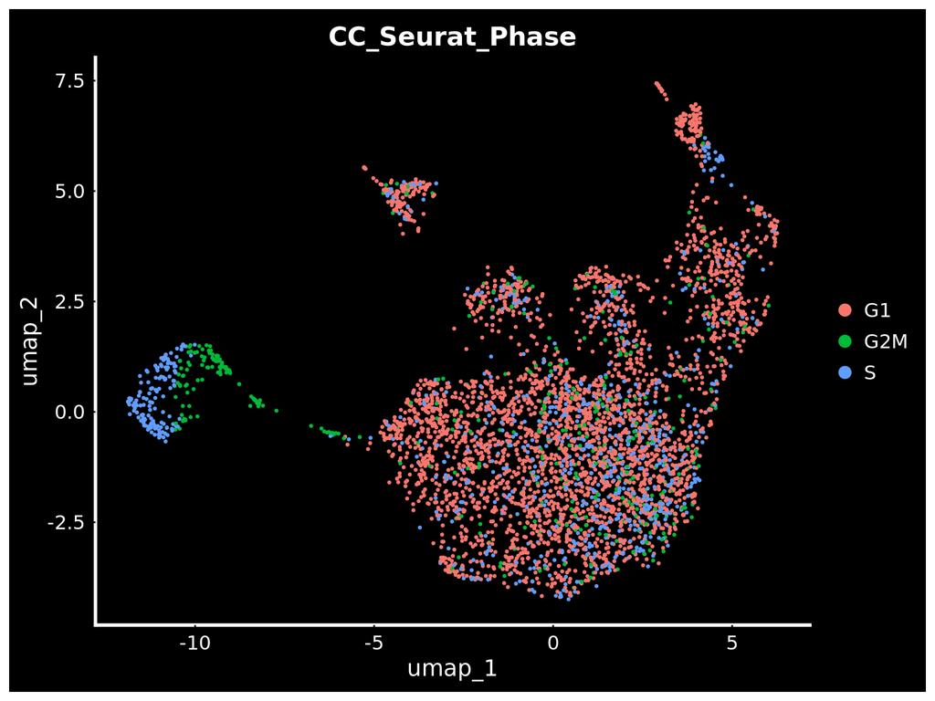

### 8.4.2 SmG2M (“S minus G2M”) score :

```r
# vizccs

## SmG2M feature plot
fp_cc <- Seurat::FeaturePlot(
  object = sobj_VIZ_cc,
  reduction = 'umap',
  features = 'CC_Seurat_SmG2M.Score') + Seurat::DarkTheme()
print(fp_cc)
```

**Show plot**

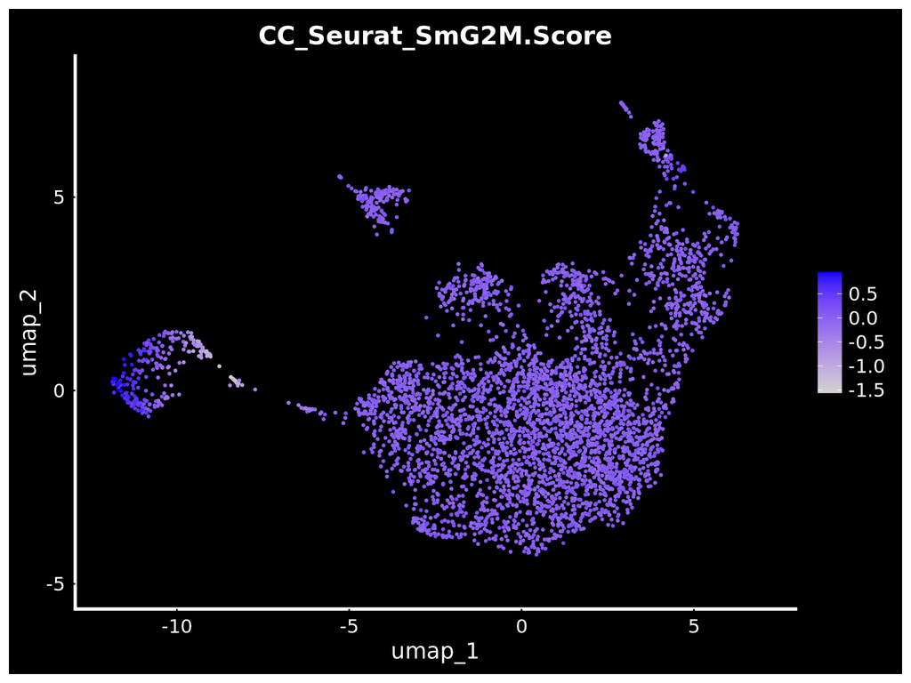

```r
## We can discard the temp object
rm(sobj_VIZ_cc)
```

## {.unnumbered}

**Questions**

```r
# q_cell1

Does the structure of the cells in this representation seem to have
a link with these cell cycle phases/scores ?
```

```r
# a_cell1

## It's an absolute yes !
```

```r
# q_cell2

Do you think this is the result of an artifact, or
biology-related ?
```

```r
# a_cell2

##
##    ¯\_(ツ)_/¯
##
```

# 9 Save the Seurat object

We will save our Seurat object that now contains the cell cycle states/scores :

```r
# saverds2

## Save our Seurat object (rich naming)
out_name <- paste0(
          output_dir, "/", paste(
            c("04", Seurat::Project(sobj), "S5",
              "CC", paste(
                dim(sobj),
                collapse = '.'
              )
            ), collapse = "_"),
            ".RDS")

## Check
print(out_name)
```

```
[1] "/shared/projects/ebaii_sc_teachers/SC_TD/03_Preproc.3/RESULTS/04_TD3A_S5_CC_12508.4278.RDS"
```

```r
## Write on disk
saveRDS(object = sobj,
        file = out_name)
```

# 10 Cell doublets

We will use **two different methods** to detect and remove cell doublets :

- [`scds`](https://www.bioconductor.org/packages/release/bioc/html/scds.html) (in its “hybrid” mode) : more efficient at detecting **homotypic** doublets
- [`scDblFinder`](https://www.bioconductor.org/packages/release/bioc/html/scDblFinder.html) : more efficient at detecting **heterotypic** doublets

None of the methods accepts a `SeuratObject` as input, but a [`SingleCellExperiment`](https://www.bioconductor.org/packages/release/bioc/html/SingleCellExperiment.html) object.

Hopefully :

- Seurat has a function to perform the conversion
- The output results can be integrated into our Seurat object with ease

## 10.1 Two methods

### 10.1.1 `scds`

```r
# scds

## Fix seed
set.seed(my_seed)

## Run scds
sobj$doublet_scds.hybrid <- unname(
  scds::cxds_bcds_hybrid(
    Seurat::as.SingleCellExperiment(
      sobj, assay = "RNA"))$hybrid_score > 1)

## Contingencies
table(sobj$doublet_scds.hybrid)
```

**Show output**

```
FALSE  TRUE
 4072   206
```

### 10.1.2 `scDblFinder`

```r
# scdbl

## Fix seed
set.seed(my_seed)

## Run scDblFinder (which needs another object type)
sobj$doublet_scDblFinder <- scDblFinder::scDblFinder(
  sce = Seurat::as.SingleCellExperiment(
    x = sobj,
    assay = "RNA"),
  returnType = "table")$class == "doublet"

## Contingencies
table(sobj$doublet_scDblFinder)
```

**Show output**

```
FALSE  TRUE
 4100   178
```

## 10.2 Merge results

We merge results of the two methods

```r
# dblmerge

## Logical union of both methods
sobj$doublet_union <- sobj$doublet_scds.hybrid | sobj$doublet_scDblFinder

## Quantify doublets
table(sobj$doublet_union)
```

**Show output**

```
FALSE  TRUE
 4035   243
```

We can assess **tool-specific** and **common** doublets

```r
# dbl_types

### Singlets by default
sobj$doublet_viz <- "singlet"

### Union
sobj$doublet_viz[sobj$doublet_union] <- "both"

### scds-specific
sobj$doublet_viz[sobj$doublet_scds.hybrid & !sobj$doublet_scDblFinder] <- "scds"

### scDblFinder-specific
sobj$doublet_viz[sobj$doublet_scDblFinder & !sobj$doublet_scds.hybrid] <- "scDblFinder"

## Convert to factor
sobj$doublet_viz <- as.factor(sobj$doublet_viz)

## Contingencies
table(sobj$doublet_viz)
```

**Show output**

```
       both scDblFinder        scds     singlet
        141          37          65        4035
```

**Beyond** : Create an upset-plot for the doublet status according to the two methods used

```r
# b_upset

## Build a list of cells tagged by one tool, the other, or both
dbl_list <-list(
  "scds" = colnames(sobj)[sobj$doublet_scds.hybrid & !sobj$doublet_scDblFinder],
  "scDblFinder" = colnames(sobj)[!sobj$doublet_scds.hybrid & sobj$doublet_scDblFinder],
  "both" = colnames(sobj)[sobj$doublet_scds.hybrid & sobj$doublet_scDblFinder])

## Draw the upset plot
UpSetR::upset(data = UpSetR::fromList(dbl_list),
              nintersects = NA,
              sets = rev(names(dbl_list)),
              keep.order = TRUE,
              order.by = "freq")
```

**Show plot**

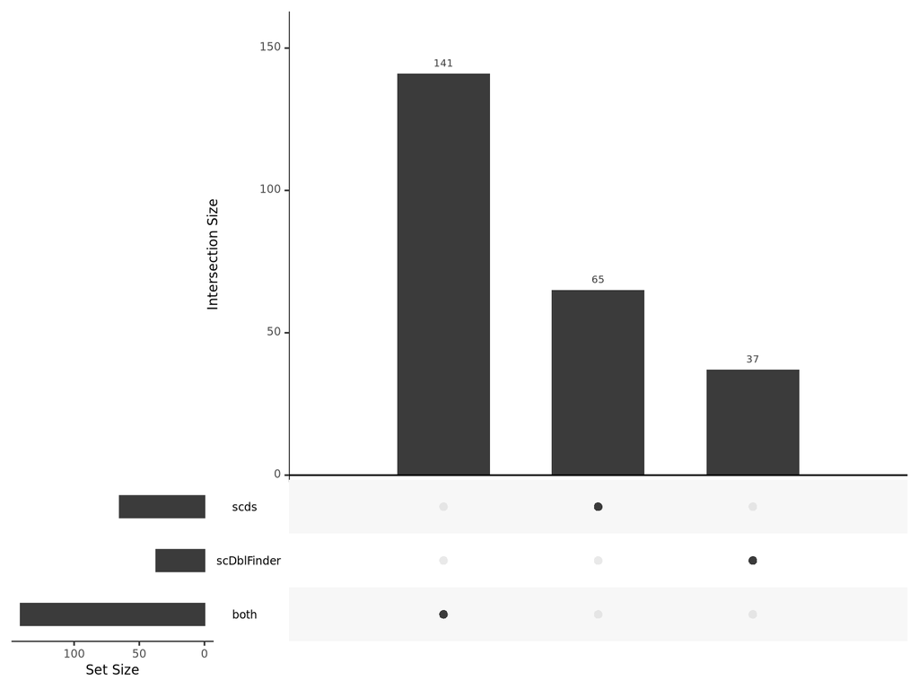

Now we can remove barcodes identified as cell doublets, and visualize the cell space before and after.

## 10.3 Doublets filtering

### 10.3.1 BEFORE

```r
# dblviz1

### Doublets viz (before removal)

## Create a temporary object
sobj_VIZ_dbl <- sobj

## Usual set of "U can't C me" functions
sobj_VIZ_dbl <- Seurat::NormalizeData(object = sobj_VIZ_dbl, verbose = FALSE)
sobj_VIZ_dbl <- Seurat::ScaleData(object = sobj_VIZ_dbl, verbose = FALSE)
sobj_VIZ_dbl <- Seurat::FindVariableFeatures(object = sobj_VIZ_dbl, verbose = FALSE)
sobj_VIZ_dbl <- Seurat::RunPCA(object = sobj_VIZ_dbl, npcs = 21, verbose = FALSE)
sobj_VIZ_dbl <- Seurat::RunUMAP(object = sobj_VIZ_dbl, dims = c(1:20), verbose = FALSE)

## Doublets visualization
dp_dbl <- Seurat::DimPlot(
  object = sobj_VIZ_dbl,
  reduction = 'umap',
  group.by = 'doublet_viz') + Seurat::DarkTheme()

## Plot
print(dp_dbl)
```

**Show plot**

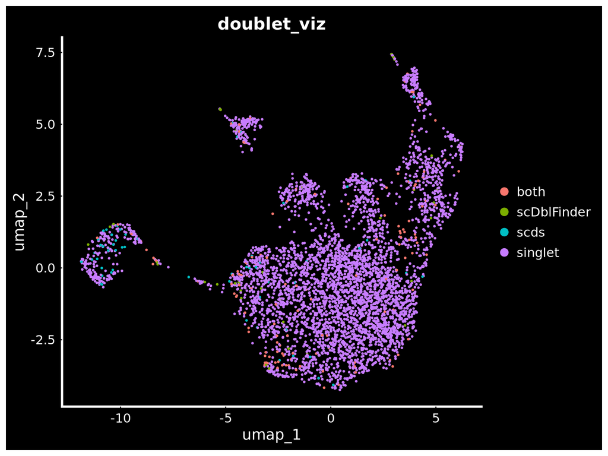

```r
## Discard temp object
rm(sobj_VIZ_dbl)
```

### 10.3.2 Remove doublets

```r
# dblrm

## Dimensions before removal
dim(sobj)
```

```
[1] 12508  4278
```

```r
## Perform the removal
# sobj <- sobj[,!sobj$doublet_union]
sobj <- subset(
  x = sobj,
  cells = colnames(sobj)[sobj$doublet_union],
  invert = TRUE)

## Dimensions after
dim(sobj)
```

```
[1] 12508  4035
```

### 10.3.3 AFTER

```r
# dblviz2

### Doublets viz (after removal)

## Create a temporary object
sobj_VIZ_dblf <- sobj

## Usual set of "U can't C me" functions
sobj_VIZ_dblf <- Seurat::NormalizeData(object = sobj_VIZ_dblf, verbose = FALSE)
sobj_VIZ_dblf <- Seurat::ScaleData(object = sobj_VIZ_dblf, verbose = FALSE)
sobj_VIZ_dblf <- Seurat::FindVariableFeatures(object = sobj_VIZ_dblf, verbose = FALSE)
sobj_VIZ_dblf <- Seurat::RunPCA(object = sobj_VIZ_dblf, npcs = 21, verbose = FALSE)
sobj_VIZ_dblf <- Seurat::RunUMAP(object = sobj_VIZ_dblf, dims = c(1:20), verbose = FALSE)

## Doublets-filtered visualization
dp_dblf <- Seurat::DimPlot(
  object = sobj_VIZ_dblf,
  reduction = 'umap',
  group.by = 'doublet_viz') + Seurat::DarkTheme()

## Plot
print(dp_dblf)
```

**Show plot**

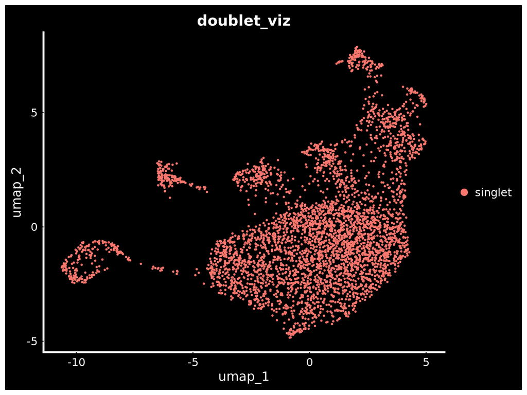

```r
## Discard temp object
rm(sobj_VIZ_dblf)
```

Merge plots for ease of use :

```r
# dbl_umaps

## Using the patchwork package to merge plots (and ggplot2 to add titles)
patchwork::wrap_plots(
  list(
    dp_dbl & ggplot2::ggtitle(label = "Cell doublets (unfiltered)"),
    dp_dblf & ggplot2::ggtitle(label = "Cell doublets (filtered)")),
  nrow = 1)
```

**Show plot**

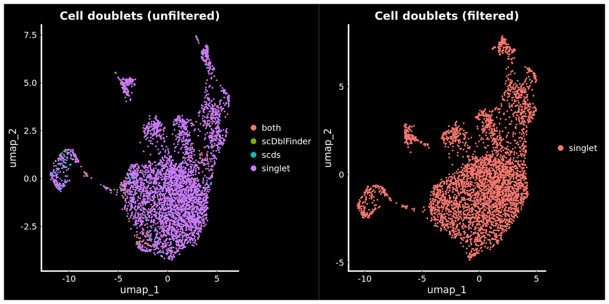

**Question**

```r
# q_dblcomp

What do you observe when comparing before and after the doublets filtering ?
```

```r
# a_dblcomp

## . Actually not that much !
##
## . This is due to the fact that this dataset did not contain
##   a lot of heterotypic doublets
##
## . When a dataset is heavily contaminated with lots of heterotypic
##   doublets, their removal can drastically remodel the topology.
```

# 11 Save the Seurat object

We will save our Seurat object that is now filtered for doublets :

```r
# saverds3

## Save our Seurat object (rich naming)
out_name <- paste0(
          output_dir, "/", paste(
            c("05", Seurat::Project(sobj), "S5",
              "Doublets.Filtered", paste(
                dim(sobj),
                collapse = '.'
              )
            ), collapse = "_"),
            ".RDS")

## Check
print(out_name)
```

**Show output**

```
[1] "/shared/projects/ebaii_sc_teachers/SC_TD/03_Preproc.3/RESULTS/05_TD3A_S5_Doublets.Filtered_12508.4035.RDS"
```

```r
## Write on disk
saveRDS(object = sobj,
        file = out_name)
```

# 12 Rsession

```r
# rsession

utils::sessionInfo()
```

[output not shown]

**Show output**